# Exploring Regional Patterns in Education, Water Access, Ethnicity, and Sanitation in The Gambia

SAIKOU CAMARA

2025-07-03

## Introduction

This report draws on data from the 2013 Gambia Demographic and Health Survey (GDHS), conducted by the Gambia Bureau of Statistics (GBOS) in collaboration with the then Ministry of Health and Social Welfare (MoHSW) and the National Population Secretariat Commission. The 2013 GDHS was the first Demographic and Health Survey carried out in The Gambia under the global DHS program—an initiative funded by the United States Agency for International Development (USAID), which provides technical and financial support for health and population surveys worldwide. The report highlights variations between rural and urban areas in terms of education, access to water, ethnicity, and sanitation facilities.

## Distribution of Educational Attainment

The two graphs highlight significant disparities in educational attainment between urban and rural populations, and also between Local Government Areas in The Gambia. Individuals residing in rural areas are disproportionately represented among those with no formal education. Conversely, urban areas show a noticeably higher percentage of individuals who have attained secondary and higher education.

Educational level also varies considerably across Local Government Areas (LGAs). The highest levels of higher education are observed in Banjul, Kanifing, and Brikama—all of which are predominantly urban. In contrast, the propotion of individuals with no formal education is greatest in the more rural LGAs, particularly Kerewan, Kuntaur, Janjangbureh, and Basse—the latter being the most geographically distant from the capital, Banjul.

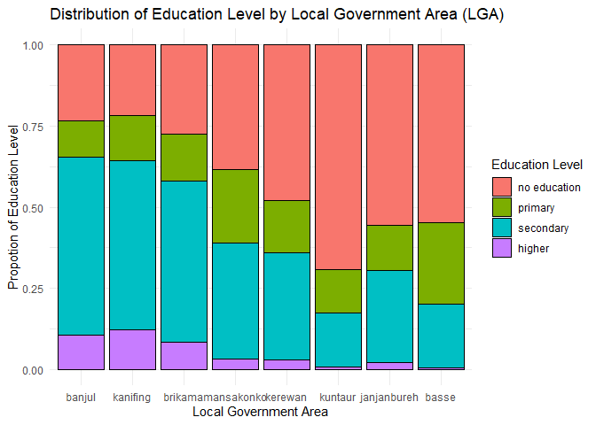

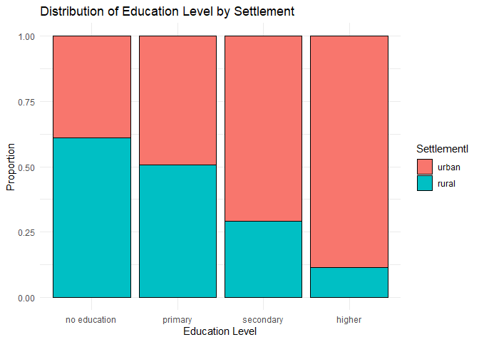

## Table: Access to Water Source by Region

Access to a water source may increase the quantity of suitable drinking water for use by households. Even if the water is obtained from an improved source, it may be contaminated during transport or storage if it is fetched from a source that is not immediately accessible to the household. The graph below shows that most of the urban population (57.3%) get their drinking water from piped borne water, while most of the rural population get their drinking water from public tap or standpipe which makes up 56.9% of water sources for drinking.

Highest Source of Drinking Water by Region

| Region | Water Source | Total Number | Percentage |
| --- | --- | --- | --- |
| urban | piped to yard/plot | 3,733 | 57.3 |
| rural | public tap/standpipe | 3,048 | 56.9 |

## Ethnic Composition Across Regions

Ethnic affiliation to certain areas can be caused by various factors including differences in cultural beliefs, norms and practices, business opportunities, etc. This survey data show that the majority of the respondents from both rural and urban areas are Mandinka/Jahanka who represent (32%) in urban and (31%) in rural areas. This is followed by the Fula/Tukulur/Lorobo ethnic group (16% in urban and 29% in rural). The minority ethnic groups across both rural and urban areas are Creole/Aku, Manjako, Bambara and Jola/Karoninka and Serere.

[interactive chart not shown]

## Educational Level and Toilet Facility Sharing

The analysis below indicates a relative association between level of educational and toilet sharing practices. 27.5% of individuals with no formal education share toilet facilities with other households, compared to 14.8% of those with higher education. This suggests that education may be linked to improved sanitation.

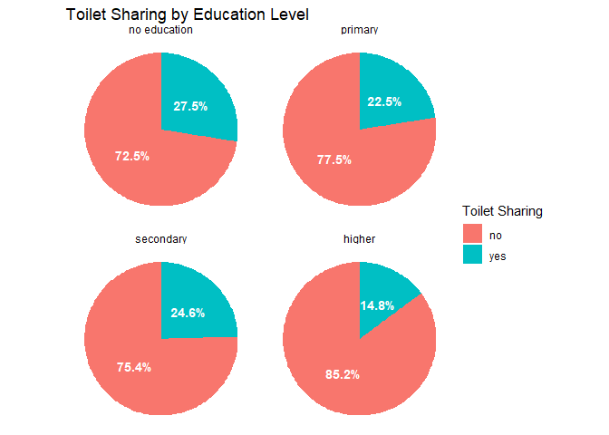

## Toilet Facility Types in Urban and Rural Areas

The data reveals stark differences in toilet facility types between urban and rural areas in The Gambia. Urban households are significantly more likely to have access to improved sanitation such as flush toilet connected to septic tank. In contrast, rural areas show a higher reliance on unimproved toilet facilities, including traditional pit latrines without slabs or just open pit.

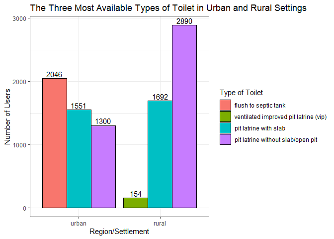

## Distribution of Unavailability of Toilet Facilities by Region

Access to toilet facilities is crucial in maintaining sanitation. The distribution of households that are with no toilet facility varies significantly across Local Government Areas (LGAs) in The Gambia. Rural LGAs, particularly Kuntaur and Kerewan, has the highest number of households or people without toilet facilities. This contrasts sharply with areas such as Banjul and Janjanbureh. Additionally, there is a certain number of people in Brikama and Mansakonko areas without toilet facilities.

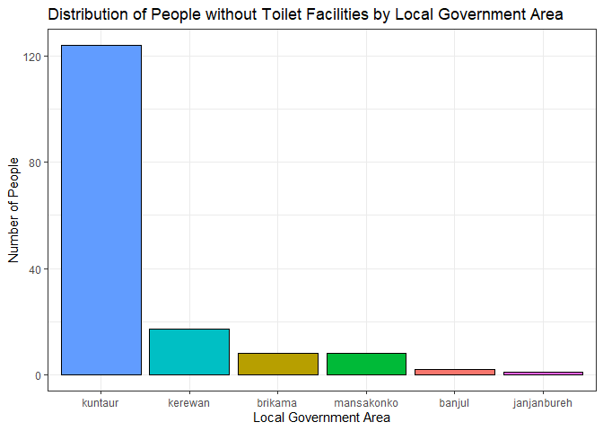

# Conclusion

The data highlights notable disparities in education, water access, sanitation, and ethnic distribution between urban and rural populations in The Gambia. Urban areas generally exhibit higher levels of educational attainment, greater access to improved water sources, and better sanitation facilities. In contrast, rural communities face significant challenges, including higher rates of individuals with no formal education, greater dependence on unimproved water and toilet facilities, and limited infrastructure.

These disparities are further reflected across Local Government Areas, with urban LGAs like Banjul, Kanifing, and Brikama showing more favorable indicators compared to rural counterparts such as Kerewan, Kuntaur, Janjanbureh, and Basse. Ethnic distribution also varies slightly, with the Mandinka/Jahanka group forming the majority across both urban and rural areas, followed by the Fula/Tukulur/Lorobo group, especially in rural communities.

The association between education and sanitation practices suggests that increased educational attainment may contribute to improved hygiene and living standards. This underscores the importance of targeted interventions aimed at enhancing education, infrastructure, and basic services in rural areas to reduce these inequalities and improve overall quality of life for all Gambians.